# Overground vs Treadmill Sprint Manuscript

# Main Analysis

## Speed

```r
model1 <- lmer(Speed ~ Sprint_Type + Group + Sex + Age + Weight + Height + Leg_Length + Thigh_Circumference + (1|ID), data = Df)
summary(model1)
AIC(model1)
BIC(model1)
```

```r
model2 <- lmer(Speed ~ Sprint_Type + Group + Sex + Leg_Length + Thigh_Circumference + (1|ID), data = Df)
summary(model2)
AIC(model2)
BIC(model2)
```

```r
model3 <- lmer(Speed ~ Sprint_Type * Group + Sex  + (1|ID), data = Df)
```

```r
tab_model(model3, show.reflvl = TRUE, p.style = "numeric_stars")
```

Speed

Predictors

Estimates

CI

p

(Intercept)

8.34 ***

7.99 – 8.69

**<0.001**

Overground

*Reference*

Treadmill

0.26 **

0.09 – 0.43

**0.003**

Track Team

*Reference*

Recreational

-1.48 ***

-1.89 – -1.07

**<0.001**

Female

*Reference*

Male

1.20 ***

0.81 – 1.60

**<0.001**

Sprint_TypeTreadmill:GroupRecreational

-0.09

-0.34 – 0.15

0.445

Random Effects

σ<sup>2</sup>

0.07

τ<sub>00</sub> <sub>ID</sub>

0.36

ICC

0.83

N <sub>ID</sub>

40

Observations

80

Marginal R<sup>2</sup> / Conditional R<sup>2</sup>

0.693 / 0.947

- p<0.05 ** p<0.01 *** p<0.001

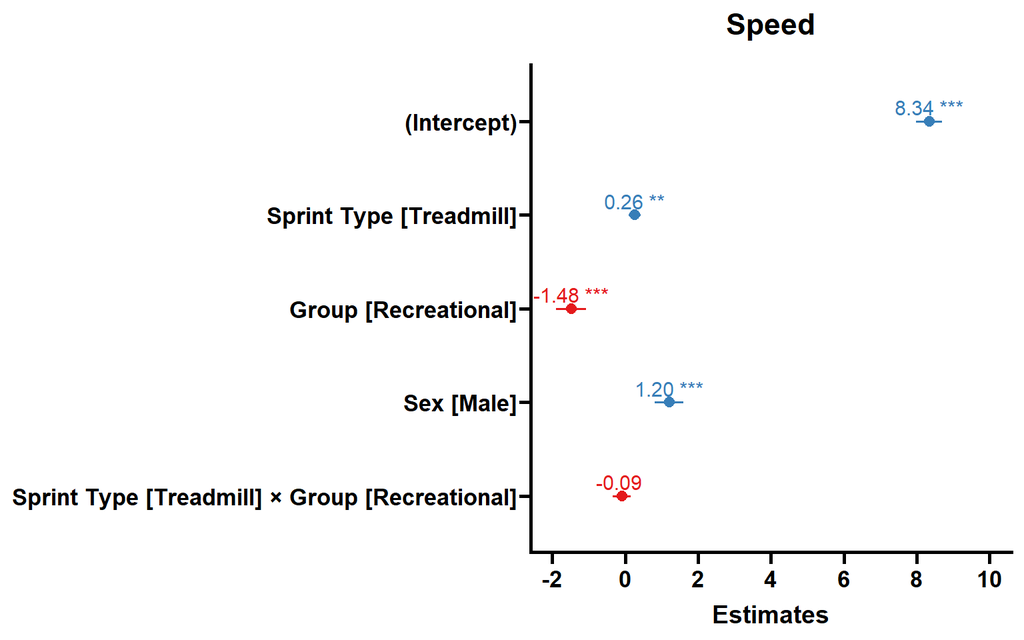

```r
plot_model(model3, show.values = TRUE, show.intercept = TRUE) + theme_prism()
```

## Contact time

```r
model4 <- lmer(Contact_Time ~ Sprint_Type + Group + Sex + Age + Weight + Height + Leg_Length + Thigh_Circumference + (1|ID), data = Df)
summary(model4)
AIC(model4)
BIC(model4)
```

```r
model5 <- lmer(Contact_Time ~ Sprint_Type + Group + Sex + Height + (1|ID), data = Df)
summary(model5)
AIC(model5)
BIC(model5)
```

```r
model6 <- lmer(Contact_Time ~ Sprint_Type * Group + Sex  + (1|ID), data = Df)
```

```r
tab_model(model6, show.reflvl = TRUE, p.style = "numeric_stars")
```

Contact_Time

Predictors

Estimates

CI

p

(Intercept)

0.14 ***

0.13 – 0.15

**<0.001**

Overground

*Reference*

Treadmill

0.01 *

0.00 – 0.02

**0.012**

Track Team

*Reference*

Recreational

0.03 ***

0.02 – 0.05

**<0.001**

Female

*Reference*

Male

-0.01 *

-0.02 – -0.00

**0.042**

Sprint_TypeTreadmill:GroupRecreational

-0.00

-0.02 – 0.01

0.747

Random Effects

σ<sup>2</sup>

0.00

τ<sub>00</sub> <sub>ID</sub>

0.00

ICC

0.45

N <sub>ID</sub>

40

Observations

80

Marginal R<sup>2</sup> / Conditional R<sup>2</sup>

0.453 / 0.697

- p<0.05 ** p<0.01 *** p<0.001

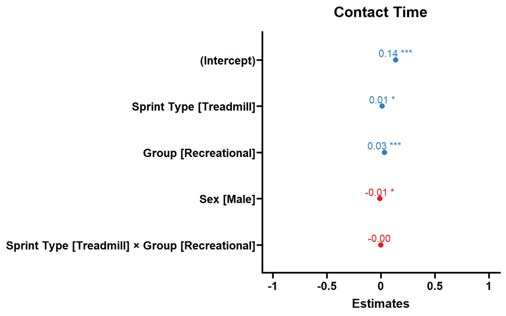

```r
plot_model(model6, show.values = TRUE, show.intercept = TRUE) + theme_prism()
```

## Flight time

```r
model7 <- lmer(Flight_Time ~ Sprint_Type + Group + Sex + Age + Weight + Height + Leg_Length + Thigh_Circumference + (1|ID), data = Df)
summary(model7)
AIC(model7)
BIC(model7)
```

```r
model8 <- lmer(Flight_Time ~ Sprint_Type + Group + Sex + Leg_Length + (1|ID), data = Df)
summary(model8)
AIC(model8)
BIC(model8)
```

```r
model9 <- lmer(Flight_Time ~ Sprint_Type * Group + Sex  + (1|ID), data = Df)
```

```r
tab_model(model9, show.reflvl = TRUE, p.style = "numeric_stars")
```

Flight_Time

Predictors

Estimates

CI

p

(Intercept)

0.12 ***

0.11 – 0.13

**<0.001**

Overground

*Reference*

Treadmill

0.04 ***

0.02 – 0.05

**<0.001**

Track Team

*Reference*

Recreational

-0.01

-0.02 – 0.01

0.294

Female

*Reference*

Male

-0.01

-0.02 – 0.00

0.141

Sprint_TypeTreadmill:GroupRecreational

-0.03 **

-0.05 – -0.01

**0.006**

Random Effects

σ<sup>2</sup>

0.00

τ<sub>00</sub> <sub>ID</sub>

0.00

ICC

0.18

N <sub>ID</sub>

40

Observations

80

Marginal R<sup>2</sup> / Conditional R<sup>2</sup>

0.371 / 0.481

- p<0.05 ** p<0.01 *** p<0.001

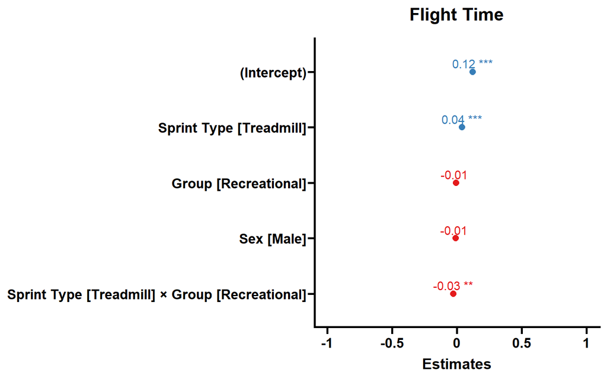

```r
plot_model(model9, show.values = TRUE, show.intercept = TRUE) + theme_prism()
```

## Stride Length

```r
model10 <- lmer(Stride_Length ~ Sprint_Type + Group + Sex + Age + Weight + Height + Leg_Length + Thigh_Circumference + (1|ID), data = Df)
summary(model10)
AIC(model10)
BIC(model10)
```

```r
model11 <- lmer(Stride_Length ~ Sprint_Type + Group + Sex  + (1|ID), data = Df)
summary(model11)
AIC(model11)
BIC(model11)
```

```r
model12 <- lmer(Stride_Length ~ Sprint_Type * Group + Sex  + (1|ID), data = Df)
```

```r
tab_model(model12, show.reflvl = TRUE, p.style = "numeric_stars")
```

Stride_Length

Predictors

Estimates

CI

p

(Intercept)

2.07 ***

1.95 – 2.19

**<0.001**

Overground

*Reference*

Treadmill

0.21 **

0.09 – 0.33

**0.001**

Track Team

*Reference*

Recreational

-0.21 **

-0.36 – -0.07

**0.006**

Female

*Reference*

Male

0.12 *

0.00 – 0.25

**0.046**

Sprint_TypeTreadmill:GroupRecreational

-0.07

-0.25 – 0.10

0.392

Random Effects

σ<sup>2</sup>

0.04

τ<sub>00</sub> <sub>ID</sub>

0.02

ICC

0.33

N <sub>ID</sub>

40

Observations

80

Marginal R<sup>2</sup> / Conditional R<sup>2</sup>

0.330 / 0.554

- p<0.05 ** p<0.01 *** p<0.001

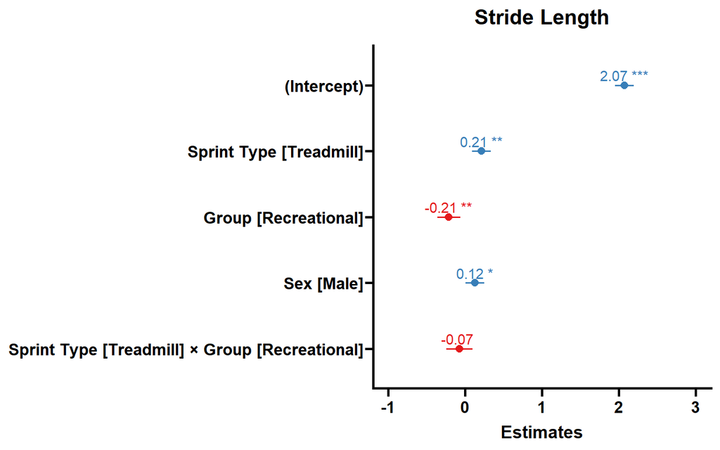

```r
plot_model(model12, show.values = TRUE, show.intercept = TRUE) + theme_prism()
```

## Stride Frequency

```r
model13 <- lmer(Stride_Frequency ~ Sprint_Type + Group + Sex + Age + Weight + Height + Leg_Length + Thigh_Circumference + (1|ID), data = Df)
summary(model13)
AIC(model13)
BIC(model13)
```

```r
model14 <- lmer(Stride_Frequency ~ Sprint_Type + Group + Sex + Leg_Length + (1|ID), data = Df)
```

```r
model15 <- lmer(Stride_Frequency ~ Sprint_Type * Group + Sex  + (1|ID), data = Df)
```

```r
tab_model(model14, show.reflvl = TRUE, p.style = "numeric_stars")
```

Stride_Frequency

Predictors

Estimates

CI

p

(Intercept)

7.35 ***

5.55 – 9.16

**<0.001**

Leg Length (cm)

-3.49 ***

-5.46 – -1.52

**0.001**

Overground

*Reference*

Treadmill

0.47 ***

0.37 – 0.57

**<0.001**

Track Team

*Reference*

Recreational

-0.50 ***

-0.69 – -0.31

**<0.001**

Female

*Reference*

Male

0.30 ***

0.13 – 0.47

**0.001**

Random Effects

σ<sup>2</sup>

0.05

τ<sub>00</sub> <sub>ID</sub>

0.04

ICC

0.46

N <sub>ID</sub>

40

Observations

80

Marginal R<sup>2</sup> / Conditional R<sup>2</sup>

0.556 / 0.760

- p<0.05 ** p<0.01 *** p<0.001

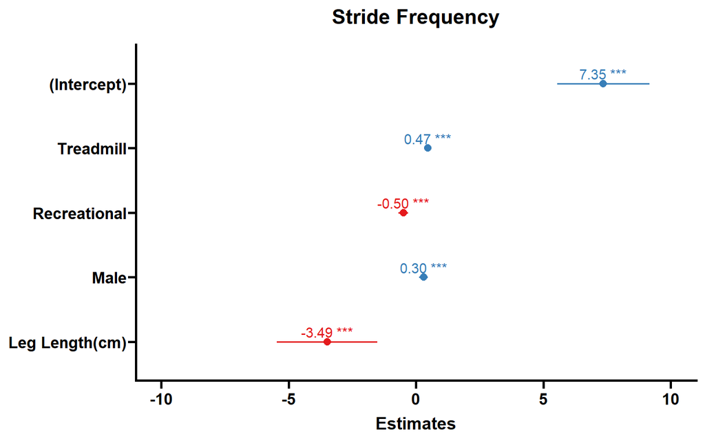

```r
plot_model(model14, show.values = TRUE, show.intercept = TRUE) + theme_prism()
```

#Results ## LMM Results Table

```r
tab_model(model3,model6,model9,model12,model14)
```

|  | Speed |  |  | Contact Time |  |  | Flight Time |  |  | Stride Length |  |  | Stride Frequency |  |  |
| --- | --- | --- | --- | --- | --- | --- | --- | --- | --- | --- | --- | --- | --- | --- | --- |
| Predictors | Estimates | CI | p | Estimates | CI | p | Estimates | CI | p | Estimates | CI | p | Estimates | CI | p |
| (Intercept) | 8.34 | 7.99 – 8.69 | **<0.001** | 0.14 | 0.13 – 0.15 | **<0.001** | 0.12 | 0.11 – 0.13 | **<0.001** | 2.07 | 1.95 – 2.19 | **<0.001** | 7.35 | 5.55 – 9.16 | **<0.001** |
| Sprint Type: Treadmill | 0.26 | 0.09 – 0.43 | **0.003** | 0.01 | 0.00 – 0.02 | **0.012** | 0.04 | 0.02 – 0.05 | **<0.001** | 0.21 | 0.09 – 0.33 | **0.001** | 0.47 | 0.37 – 0.57 | **<0.001** |
| Group: Recreational | -1.48 | -1.89 – -1.07 | **<0.001** | 0.03 | 0.02 – 0.05 | **<0.001** | -0.01 | -0.02 – 0.01 | 0.294 | -0.21 | -0.36 – -0.07 | **0.006** | -0.50 | -0.69 – -0.31 | **<0.001** |
| Sex: Male | 1.20 | 0.81 – 1.60 | **<0.001** | -0.01 | -0.02 – -0.00 | **0.042** | -0.01 | -0.02 – 0.00 | 0.141 | 0.12 | 0.00 – 0.25 | **0.046** | 0.30 | 0.13 – 0.47 | **0.001** |
| Sprint_TypeTreadmill:GroupRecreational | -0.09 | -0.34 – 0.15 | 0.445 | -0.00 | -0.02 – 0.01 | 0.747 | -0.03 | -0.05 – -0.01 | **0.006** | -0.07 | -0.25 – 0.10 | 0.392 |  |  |  |
| Leg Length(cm) |  |  |  |  |  |  |  |  |  |  |  |  | -3.49 | -5.46 – -1.52 | **0.001** |
| Random Effects |  |  |  |  |  |  |  |  |  |  |  |  |  |  |  |
| σ<sup>2</sup> | 0.07 |  |  | 0.00 |  |  | 0.00 |  |  | 0.04 |  |  | 0.05 |  |  |
| τ<sub>00</sub> | 0.36 <sub>ID</sub> |  |  | 0.00 <sub>ID</sub> |  |  | 0.00 <sub>ID</sub> |  |  | 0.02 <sub>ID</sub> |  |  | 0.04 <sub>ID</sub> |  |  |
| ICC | 0.83 |  |  | 0.45 |  |  | 0.18 |  |  | 0.33 |  |  | 0.46 |  |  |
| N | 40 <sub>ID</sub> |  |  | 40 <sub>ID</sub> |  |  | 40 <sub>ID</sub> |  |  | 40 <sub>ID</sub> |  |  | 40 <sub>ID</sub> |  |  |
| Observations | 80 |  |  | 80 |  |  | 80 |  |  | 80 |  |  | 80 |  |  |
| Marginal R<sup>2</sup> / Conditional R<sup>2</sup> | 0.693 / 0.947 |  |  | 0.453 / 0.697 |  |  | 0.371 / 0.481 |  |  | 0.330 / 0.554 |  |  | 0.556 / 0.760 |  |  |

## LMM estimates

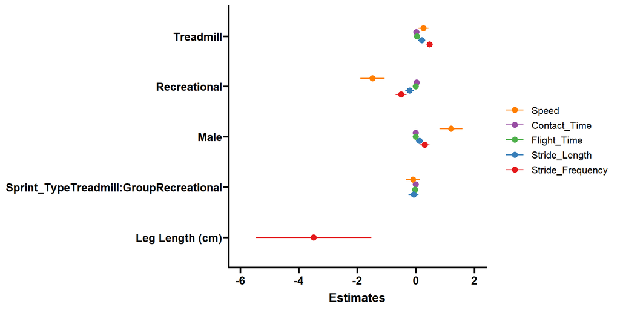

```r
plot_models(model3,model6,model9,model12,model14) + theme_prism()
```

##Table 2

```r
label(Df$Speed)   <- "Speed (m/s)"
label(Df$Contact_Time)   <- "Contact Time (s)"
label(Df$Flight_Time)   <- "Flight Time (s)"
label(Df$Stride_Length)   <- "Stride Length (m)"
label(Df$Stride_Frequency   )   <- "Stride Frequency (Hz)"

caption  <- "Table 2. Sprint Kinematics for each Sprint Type by Training Group and Sex"


table1(~Speed + Contact_Time + Flight_Time + Stride_Length + Stride_Frequency | Group*Sex, data=Df, caption=caption, overall = FALSE)
```

Table 2. Sprint Kinematics for each Sprint Type by Training Group and Sex

|  | Track Team Female (N=20) | Track Team Male (N=20) | Recreational Female (N=20) | Recreational Male (N=20) |
| --- | --- | --- | --- | --- |
| Speed (m/s) |  |  |  |  |
| Mean (SD) | 8.52 (0.646) | 9.63 (0.677) | 6.89 (0.685) | 8.20 (0.612) |
| Median [Min, Max] | 8.37 [7.51, 10.1] | 9.83 [8.27, 10.7] | 6.82 [5.71, 8.27] | 8.17 [7.38, 9.83] |
| Contact Time (s) |  |  |  |  |
| Mean (SD) | 0.139 (0.0220) | 0.133 (0.0146) | 0.175 (0.0236) | 0.160 (0.0184) |
| Median [Min, Max] | 0.142 [0.0650, 0.168] | 0.131 [0.102, 0.158] | 0.180 [0.114, 0.214] | 0.161 [0.117, 0.194] |
| Flight Time (s) |  |  |  |  |
| Mean (SD) | 0.146 (0.0372) | 0.124 (0.0253) | 0.111 (0.0195) | 0.116 (0.0196) |
| Median [Min, Max] | 0.135 [0.0980, 0.245] | 0.114 [0.0990, 0.178] | 0.111 [0.0820, 0.154] | 0.109 [0.0860, 0.159] |
| Stride Length (m) |  |  |  |  |
| Mean (SD) | 2.19 (0.304) | 2.28 (0.199) | 1.91 (0.273) | 2.07 (0.213) |
| Median [Min, Max] | 2.13 [1.89, 3.09] | 2.25 [2.02, 2.72] | 1.83 [1.63, 2.94] | 2.00 [1.64, 2.52] |
| Stride Frequency (Hz) |  |  |  |  |
| Mean (SD) | 4.44 (0.557) | 4.54 (0.348) | 4.04 (0.361) | 4.31 (0.312) |
| Median [Min, Max] | 4.44 [3.27, 5.88] | 4.45 [4.10, 5.52] | 4.04 [3.27, 4.81] | 4.27 [3.79, 4.90] |